# RTI Data Science Exercise Steps 5, 6, and 7

### Step 4. Variable Transformation and Creation

The transformations are done based on discoveries made by looking at variable associations with the response.  
The code behind the functions ‘transform_logistic’ and ‘transform_forest’ can be found at the end of the page.

**Logistic Regression Dataset, Variable Transformations**

- capital_gain : scaled by a natural log
- marital_status : 1 for values of ‘Married-AF-spouse’, ‘Married-civ-spouse’, and 0 otherwise
- workclass : The NA values within workclass are given a separate category of ‘missing’
- occupation : The NA values within occupation are given a separate category of ‘missing’

**Randon Forest Dataset, Variable Transformations**

- workclass : The NA values within workclass are given a separate category of ‘missing’
- occupation : The NA values within occupation are given a separate category of ‘missing’

```r
#read in data
library(tidyverse)
raw_train <- read_csv('C:/Users/Will/Documents/MSA/jobs/rti_challenge/data-scientist-exercise01/data/train.csv')
raw_valid <- read_csv('C:/Users/Will/Documents/MSA/jobs/rti_challenge/data-scientist-exercise01/data/valid.csv')
raw_test <- read_csv('C:/Users/Will/Documents/MSA/jobs/rti_challenge/data-scientist-exercise01/data/test.csv')


#transform the data
train_logistic <- transform_logistic(raw_train)
valid_logistic <- transform_logistic(raw_valid)
test_logistic <- transform_logistic(raw_test)

train_forest <- transform_forest(raw_train)
valid_forest <- transform_forest(raw_valid)
test_forest <- transform_forest(raw_test)
```

### Step 5: Model Building

The code behind the function ‘calculate_ROC’ can be found at the end of the page.

#### **Random Forest**

I’ll start out with a random forest model so I can get an idea of variable importance on each variable. This will also help me decide which variables to include in the logistic regression model. I didn’t go into any parameter tuning when building this model.

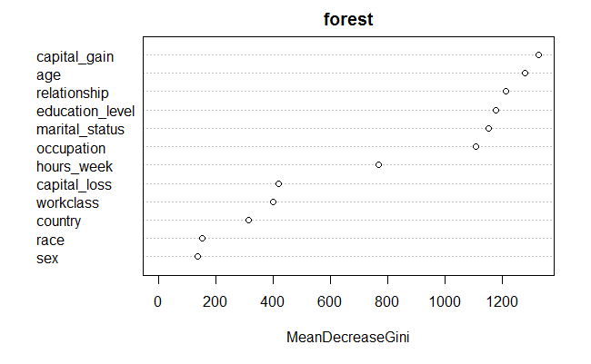

It was interesting to see that the variable ‘relationship’ had such a high mean decrease in gini. Because of this finding I didn’t combine levels of the relationship variable when building the logistic regression model.

#### **Random Forest Evaluation**

The Random forest is evaluated by looking at the accuracy, AUC and ROC curve.

```r
#Calculate predicted probabilities on the validation data set
forest_probs <- predict(forest,newdata = valid_forest, type = 'prob')[,2]

#calculate ROC curve
forest_roc <- calculate_ROC(probs = forest_probs, response = valid_forest$over_50k, name =  'Random Forest')

#create table of summary stats
summary_stats_forest <- data.frame(model = 'Random Forest',
                            max_accuracy = max(forest_roc$accuracy),
                            auc =  forest_roc$AUC[1])
```

```r
print(summary_stats)
```

| model | max_accuracy | auc |
| --- | --- | --- |
| Random Forest | 0.8476814 | 0.885488 |

The Random Forest ROC curve give me an idea of the separation between the response values across an array of cutoff thresholds

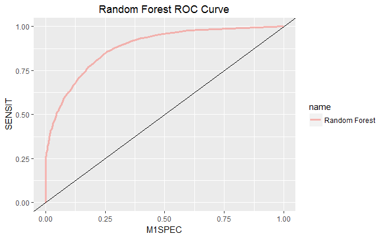

#### **Logistic Regression**

The following model inputs were decided upon while examining the variable associations with the response.

- poly(age,3)
- education_num
- capital_gain + capital_gain_ind
- capital_loss_ind
- poly(hours_week,3) + hours_week_ind + I(hours_week_ind * hours_week)
- country_group
- marital_status | relationship
- occupation | workclass

I will also include race and gender in the model but I would hope the variation explained by both of these variables should be explained better by underlying factors such as education, age, hours worked, and work class.

To begin modeling I run all the variables, including the interaction and polynomial terms, through a forward, backward, and stepwise selection model.

```r
#define full logistic model
full_logistic_mod <- glm(over_50k ~ poly(age,3) +
                                    education_num +
                                    capital_gain + capital_gain_ind +
                                    capital_loss_ind +
                                    poly(hours_week,3) + hours_week_ind + I(hours_week_ind * hours_week) +
                                    relationship +
                                    marital_status +
                                    occupation + country_group + sex + race, data = train_logistic, family = binomial)


#define empty model
nothing <- glm(over_50k ~ 1,data = train_logistic, family = binomial)


#preform backwards, forwards, and stepwise selection, while optimizing AIC
backwards <-step(full_logistic_mod, trace = 0) # Backwards selection is the default

forwards <- step(nothing,
                 scope=list(lower=formula(nothing),upper=formula(full_logistic_mod)), direction="forward", trace = 0)

stepwise <- step(nothing, list(lower=formula(nothing),upper=formula(full_logistic_mod)),
                 direction="both",trace=0)
```

Based on variable selection results, I chose to look further into 3 potential models :

- **Model 1** contains all the variables from the selected model of the forwards selection technique
- **Model 2** takes the inputs of Model 1 except it drops sex, country, marital_status, and race, and adds back in the hours_week indicator and the hours_week interaction
- **Model 3** has the inputs of Model 2, except it drops the occupation variable

In this process I am looking for the simplest model that still maintains a high level of accuracy

```r
#Model 1: Forward Selection Model
model1 <- glm(over_50k ~ relationship + education_num + capital_gain + capital_gain_ind + poly(age,3) +
               occupation + poly(hours_week,3) + capital_loss_ind + sex + country_group + marital_status + race, data = train_logistic,
                family = binomial)

#Model 2: Forward Selection model w/ fewer variables
model2 <- glm(over_50k ~ relationship + education_num + capital_gain + capital_gain_ind + poly(age,3) +
                         occupation + poly(hours_week,3) + hours_week_ind + I(hours_week_ind * hours_week) +
                         capital_loss_ind, data = train_logistic, family = binomial)


#Model 3: Same variables as Model 2 except this time I am removing occupation.
model3 <- glm(over_50k ~ relationship + education_num + capital_gain + capital_gain_ind + poly(age,3) +
                         poly(hours_week,3) + hours_week_ind + I(hours_week_ind * hours_week) +
                         capital_loss_ind, data = train_logistic, family = binomial)
```

Now that I have built the logistic regression models, I’ll first compare some performance metrics of the models and then compare their ROC curves

| model | max_accuracy | auc |
| --- | --- | --- |
| logistic_1 | 0.8567152 | 0.9138395 |
| logistic_2 | 0.8572014 | 0.9111642 |
| logistic_3 | 0.8541304 | 0.9060169 |

Now lets examine the comparison in ROC curves between the models

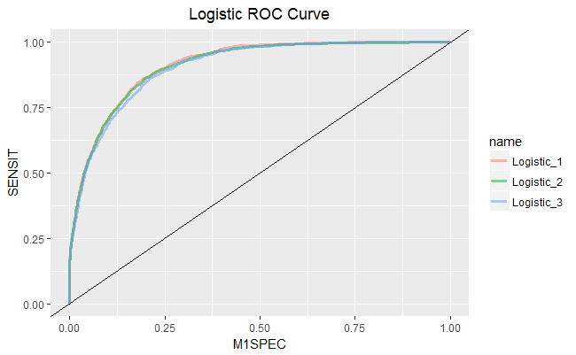

Model 2 seems to be the simplest model that still maintains a high model AUC and accuracy.

I did apply the LASSO penalty to Model 2 to see if the model was overfitting the data, but the penalty ended up being extremely small and none of the variables were dropped.

#### **Ensemble Model**

The Ensemble model is a combination of logistic regression and random forest. The ensemble in this case is an average of the predictions out of the two models.

The ensemble is evaluated by looking at the accuracy, AUC and ROC curve.

```r
#Ensemble with a basic probability average
ensemble_probs <- (forest_probs + model2_probs) / 2

#Calculate Ensemble ROC curve
ensemble_roc <- calculate_ROC(probs = ensemble_probs, response = valid_forest$over_50k, name =  'ensemble')

#create table of summary stats
summary_stats_ensemble <- data.frame(model = 'Ensemble',
                            max_accuracy = max(ensemble_roc$accuracy),
                            auc =  ensemble_roc$AUC[1])
```

| model | max_accuracy | auc |
| --- | --- | --- |
| Ensemble | 0.8607841 | 0.9156157 |

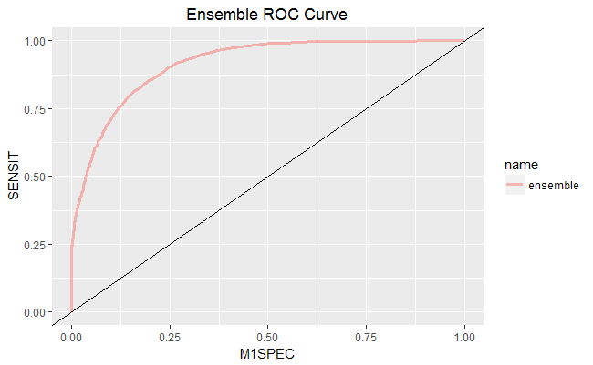

```r
ggplot(ensemble_roc, aes(x = M1SPEC, y = SENSIT)) + geom_line(aes(color = name), lwd = 1.3, alpha= 0.5) +
  geom_abline(slope = 1, intercept = 0) + xlim(0,1) + ylim(0,1) + ggtitle('Ensemble ROC Curve') +
  theme(plot.title = element_text(hjust = 0.5))
```

### Step 6: Model Comparison and Final Selection

To compare the three models: Random Forest, Logistic Regression and the Ensemble, I examine the differences in accuracy, AUC and ROC curve.

|  | model | max_accuracy | auc |
| --- | --- | --- | --- |
| 1 | Random Forest | 0.8476814 | 0.8854880 |
| 2 | Ensemble | 0.8607841 | 0.9156157 |
| 21 | logistic_2 | 0.8572014 | 0.9111642 |

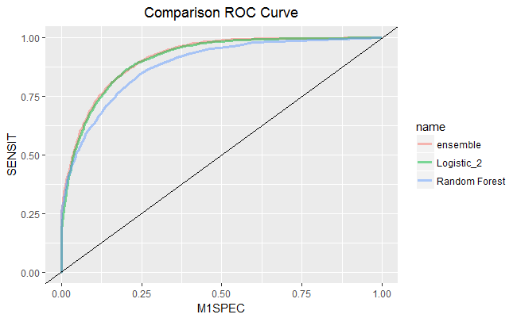

The Final Selected model is the logistic regression model. I choose this model because it has a significant lift over just the random forest model, and the improvements made by the ensemble aren’t large enough to justify losing the interpretability of the logistic regression model.

## **Test Set Accuracy**

### Predicting on the test set, with the cutoff threshold selected which resulted in the highest acuracy on the validation set: The Overall Accuracy was 85.2% Correct

```r
caret::confusionMatrix( predictions, raw_test$over_50k)
```

```
Confusion Matrix and Statistics

          Reference
Prediction    0    1
         0 3415  476
         1  245  747

               Accuracy : 0.8523
                 95% CI : (0.8421, 0.8622)
    No Information Rate : 0.7495
    P-Value [Acc > NIR] : < 2.2e-16

                  Kappa : 0.5803
 Mcnemar's Test P-Value : < 2.2e-16

            Sensitivity : 0.9331
            Specificity : 0.6108
         Pos Pred Value : 0.8777
         Neg Pred Value : 0.7530
             Prevalence : 0.7495
         Detection Rate : 0.6994
   Detection Prevalence : 0.7968
      Balanced Accuracy : 0.7719

       'Positive' Class : 0
```

#### Function Code:

```r
transform_logistic <- function(data){

  data %>%
    mutate(education_num = ifelse(education_num < 8, 7, education_num),
           capital_gain = log(capital_gain + 1),
           capital_gain_ind = ifelse(capital_gain == 0,1,0),
           capital_loss_ind = ifelse(capital_loss == 0, 0, 1),
           hours_week_ind = ifelse(hours_week >= 50, 1,0),
           workclass = ifelse(is.na(workclass), 'missing', as.character(workclass)),
           occupation = ifelse(is.na(occupation), 'missing', as.character(occupation)),
           marital_status = ifelse(marital_status %in% c('Married-AF-spouse', 'Married-civ-spouse'), 1,0)) %>%
    group_by(country) %>%
    mutate(pct_over_50k = sum(as.numeric(as.character(over_50k)))/n()) %>%
    mutate(country_group = cut(pct_over_50k, seq(0,.46, by = .051), labels = letters[1:9])) %>%
    ungroup() %>%
    mutate_each(funs(factor(.)), -c(age:hours_week, capital_gain_ind, hours_week_ind)) %>%
    select(-split_number) -> transformed_data

  return(transformed_data)

}


transform_forest <- function(data){
  data[is.na(data)] <- 'missing'
  data %>%
    mutate_each(funs(as.factor(.)), -c(age:hours_week)) %>%
    select(-split_number, -education_num) -> data

  return(data)
}
```

```r
#' Calculate the ROC curve for a given model
#' @description This function calculates the roc curve and returns the data in a data frame
#' @param model  model of interest
#' @param response  response variable
#' @param name  name of model
#' @param probs predicted probabilities
#' @export
calculate_ROC <- function(model = NULL, response, name, probs = NULL){
  df <- NULL
  tp_rates <- NULL
  fp_rates <- NULL
  probs <- if(is.null(probs)){predict(model, type= 'response')} else{probs}
  AUC <- as.numeric(pROC::auc(response, probs))
  for(threshold in 0:200){
    preds <- ifelse(probs >= (threshold/200), 1,0)
    confusion_matrix <- caret::confusionMatrix(preds, response)$table
    POS <- confusion_matrix[2,2]
    NEG <- confusion_matrix[1,1]
    FALPOS <- confusion_matrix[2,1]
    FALNEG <- confusion_matrix[1,2]
    tp_rate <- POS / (POS + FALNEG)
    fp_rate <- FALPOS / (NEG + FALPOS)
    tn_rate <- NEG / (NEG + FALPOS)
    SPECIFICITY  <- tn_rate
    SENSIT <- tp_rate
    M1SPEC <- 1 - SPECIFICITY
    df <- rbind(df, data.frame(name, AUC,'PROB' = threshold/200,
                               POS, NEG, FALPOS, FALNEG, SENSIT,
                               M1SPEC, youden_index = (SENSIT + SPECIFICITY - 1),
                               accuracy = (POS + NEG)/(POS + NEG + FALPOS + FALNEG)))

  }

  return(df)
}
```